[figure not shown]

# Teorema Central del Límite

## Métodos Monte Carlo en R

1. Introducción
2. TCL
3. Paquetes R
4. Muestreo
5. Cara / Cruz
6. Pi Monte Carlo
7. Redes Sociales

# Introducción

Por muchos considerado el resultado más importante de las matemáticas, el teorema central del límite, en la teoría de la probabilidad, establece a la distribución Normal como la distribución a la que la media de casi cualquier conjunto de variables independientes y generadas aleatoriamente converge rápidamente. El teorema central del límite explica por qué la distribución Normal surge con tanta frecuencia y por qué generalmente es una excelente aproximación de la media de una recopilación de datos (a veces con tan sólo 10 variables).  
Encyclopedia Britannica (2019).  
Central Limit Theorem.

En este proyecto desarrollaremos ejercicios para representar, ayudar a comprender y aplicar el teorema central del límite realizando experimentos Monte Carlo (aleatorios).  
Todos los desarrollos de Pakin Ciencia de Datos son dinámicos por lo que periódicamente se añaden nuevos ejercicios a este proyecto. Al final de la página puedes comentarnos e incluso solicitar o sugerir el desarrollo de algún ejercicio o aplicación en particular.

Regresar al menú

# Teorema Central del Límite

Sea $X_{1}, X_{2},...$ una sucesión infinita de variables aleatorias independientes e idénticamente distribuidas, con media $\mu$ y varianza finita $\sigma^2$. Entonces la función de distribución de la variable aleatoria:

$$ Z_{n} = \frac{(X_{1} +...+X_{n}) - n\mu}{\sqrt{n\sigma^2}}$$

tiende a la función de distribución normal estándar cuando *n* tiende a infinito.  
Rincón, L. (2014), *Introducción a la Probabilidad*, México CDMX, Las prensas de ciencias.  
Aquí puedes descargar el libro: [Introducción a la Probabilidad.](http://lya.fciencias.unam.mx/lars/Publicaciones/Prob1-2014.pdf)  
En palabras más simples, el TCL nos dice que si tomamos muestras lo suficientemente grandes (>=30) de una cierta población, la media de esas muestras seguirá una distribución normal sin importar que distribución siga la población.

Regresar al menú

# Paquetes R

```r
library(ggplot2)
library(plotly)
library(dplyr)
library(lubridate)
```

```r
print(paste0("Última ejecución: ", date()))
```

```
[1] "Última ejecución: Mon Jun 14 19:35:47 2021"
```

Regresar al menú

# Muestreo Aleatorio

Vamos a importar un conjunto de datos correspondientes a un estudio de desempeño de estudiantes. Puedes encontrar el conjunto de datos en UCI Machine Learning Repository.  
[Student Performance](https://archive.ics.uci.edu/ml/datasets/Student+Performance)  
Nos centraremos en el campo (columna) de ausencias (absences).

```r
data <- read.csv("/home/pakin/Documents/desarrolloWeb/PakinV5/student-por.csv", header = TRUE)

datos <- data$absences

print("Cantidad de datos")

length(datos)

print("Media de las ausencias")

mp = round(mean(datos), 2)

data[1:5, 1:8]
```

```
[1] "Cantidad de datos"
```

649

```
[1] "Media de las ausencias"
```

A data.frame: 5 × 8

| school <fct> | sex <fct> | age <int> | address <fct> | famsize <fct> | Pstatus <fct> | Medu <int> | Fedu <int> |
| --- | --- | --- | --- | --- | --- | --- | --- |
| GP | F | 18 | U | GT3 | A | 4 | 4 |
| GP | F | 17 | U | GT3 | T | 1 | 1 |
| GP | F | 15 | U | LE3 | T | 1 | 1 |
| GP | F | 15 | U | GT3 | T | 4 | 2 |
| GP | F | 16 | U | GT3 | T | 3 | 3 |

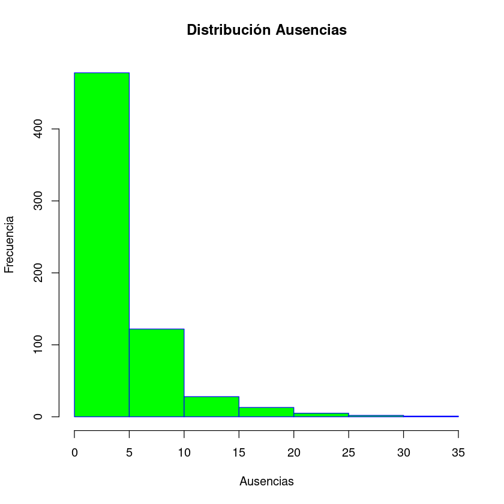

```r
hist(datos, main = "Distribución Ausencias", xlab = "Ausencias", ylab = "Frecuencia",
    col = "green", border = "blue")
```

```r
n <- 10

m <- 10

Medias <- vector("numeric", length = m)

for (i in 1:m) {

    Medias[i] <- mean(sample(datos, size = n, replace = TRUE))
}

print("Observemos las Medias")

head(round(Medias, 2), 30)

print("Media de las ausencias")

mp

print("Media de las muestras")

round(mean(Medias), 2)
```

```
[1] "Observemos las Medias"
```

1. 5.4

2. 4.6

3. 1.2

4. 4

5. 2.2

6. 3.9

7. 5.8

8. 2.3

9. 7.7

10. 3.4

```
[1] "Media de las ausencias"
```

3.66

```
[1] "Media de las muestras"
```

4.05

```r
options(repr.plot.width = 6, repr.plot.height = 5)
```

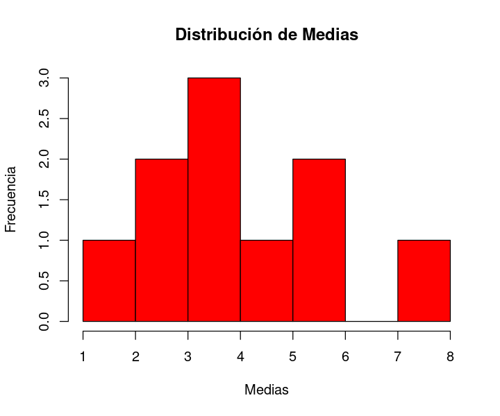

```r
hist(Medias, main = "Distribución de Medias", col = "red", ylab = "Frecuencia")
```

```r
n <- 50
m <- 10

Medias <- vector("numeric", length = m)

for (i in 1:m) {

    Medias[i] <- mean(sample(datos, size = n, replace = TRUE))
}

print("Observemos las Medias")

head(round(Medias, 2), 30)

print("Media de las ausencias")

mp

print("Media de las muestras")

round(mean(Medias), 2)
```

```
[1] "Observemos las Medias"
```

1. 2.76

2. 3.46

3. 2.28

4. 4.08

5. 2.2

6. 4.2

7. 4.48

8. 3.06

9. 4.94

10. 3.36

```
[1] "Media de las ausencias"
```

3.66

```
[1] "Media de las muestras"
```

3.48

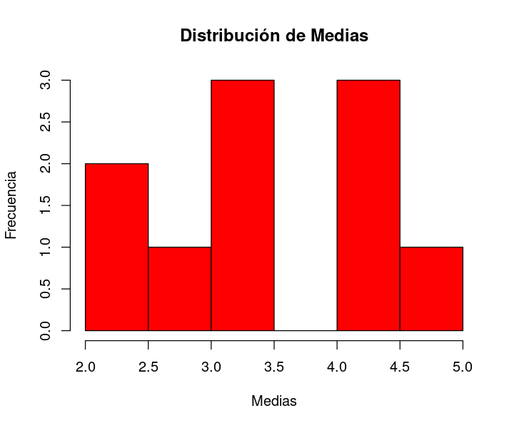

```r
hist(Medias, main = "Distribución de Medias", col = "red", ylab = "Frecuencia")
```

## Incrementemos el número y el tamaño de las muestras:

```r
n <- 100
m <- 100

Medias <- vector("numeric", length = m)

for (i in 1:m) {

    Medias[i] <- mean(sample(datos, size = n, replace = TRUE))
}

print("Observemos las Medias")

head(round(Medias, 2), 30)

print("Media de las ausencias")

mp

print("Media de las muestras")

round(mean(Medias), 2)
```

```
[1] "Observemos las Medias"
```

1. 3.52

2. 3.9

3. 3.24

4. 3.54

5. 3.82

6. 4

7. 4.03

8. 3.42

9. 3.64

10. 4.76

11. 3.71

12. 2.87

13. 4.44

14. 3.86

15. 3.64

16. 3.14

17. 2.97

18. 3.67

19. 4.53

20. 3.65

21. 3.17

22. 3.33

23. 3.02

24. 3.92

25. 2.85

26. 3.55

27. 3.79

28. 3.56

29. 4.01

30. 3.22

```
[1] "Media de las ausencias"
```

3.66

```
[1] "Media de las muestras"
```

3.73

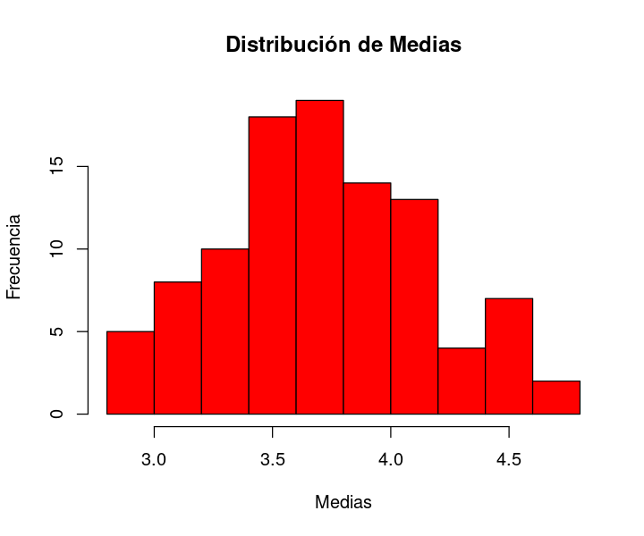

```r
hist(Medias, main = "Distribución de Medias", col = "red", ylab = "Frecuencia")
```

```r
n <- 20000
m <- 300

Medias <- vector("numeric", length = m)

for (i in 1:m) {

    Medias[i] <- mean(sample(datos, size = n, replace = TRUE))
}

print("Observemos las Medias")

head(round(Medias, 2), 30)

print("Media de las ausencias")

mp

print("Media de las muestras")

round(mean(Medias), 2)
```

```
[1] "Observemos las Medias"
```

1. 3.69

2. 3.67

3. 3.69

4. 3.65

5. 3.67

6. 3.62

7. 3.7

8. 3.68

9. 3.63

10. 3.63

11. 3.63

12. 3.61

13. 3.66

14. 3.65

15. 3.59

16. 3.64

17. 3.67

18. 3.76

19. 3.73

20. 3.68

21. 3.67

22. 3.64

23. 3.65

24. 3.65

25. 3.69

26. 3.63

27. 3.68

28. 3.64

29. 3.64

30. 3.71

```
[1] "Media de las ausencias"
```

3.66

```
[1] "Media de las muestras"
```

3.66

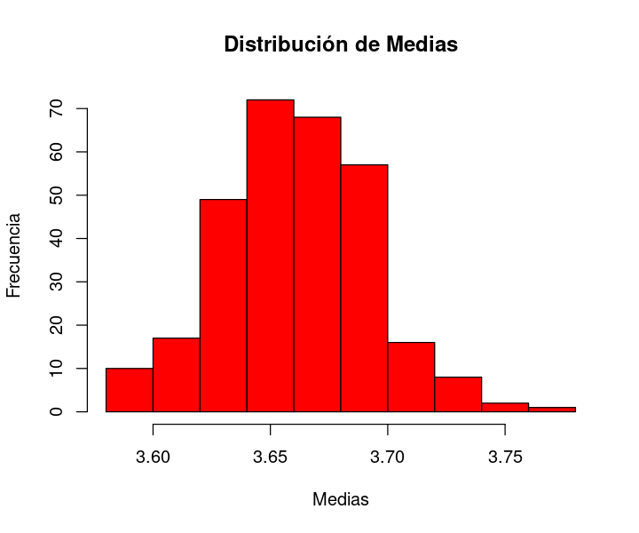

```r
hist(Medias, main = "Distribución de Medias", col = "red", ylab = "Frecuencia")
```

- ¿Qué podemos decir acerca de esta última distribución?
- ¿Qué podemos decir de su media?
- ¿Qué podemos decir de su desviación estándar?

Regresar al menú

# Métodos Monte Carlo

Los métodos Monte Carlo son procedimientos no deterministas que pueden ser utilizados para aproximar y/o simular variables aleatorias, su nombre hace referencia al Casino de Monte Carlo en Mónaco por ser un ícono de los juegos de azar.

# Simulación Monte Carlo: Lanzamientos de una Moneda

Con la creación de un sencillo ciclo *for* simularemos lanzamientos de una moneda (justa) en donde se representará la cara de la moneda con el número **1** y la cruz con el numero **2**. Haremos **m** repeticiones de **n** lanzamientos cada repetición y nos fijaremos en el número de veces que aparece la cara (1) y promediaremos (media) este número de veces que a su vez acumularemos en un vector llamado **Resultados**.

Comencemos con 10 repeticiones de 10 lanzamientos cada repetición:

```r
n <- 10
m <- 10

Resultados <- vector("numeric", length = m)

for (i in 1:m) {

    Resultados[i] <- mean(sample(1:2, size = n, replace = TRUE) == 1)

}

Resultados
```

1. 0.2

2. 0.4

3. 0.4

4. 0.1

5. 0.3

6. 0.5

7. 0.5

8. 0.5

9. 0.7

10. 0.5

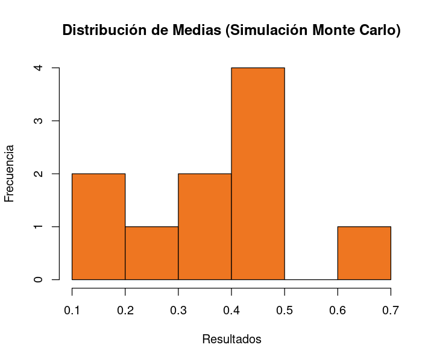

```r
hist(Resultados, main = "Distribución de Medias (Simulación Monte Carlo)", col = "chocolate2",
    ylab = "Frecuencia")
```

## Incrementemos el número de lanzamientos por repetición:

```r
n <- 100
m <- 10

Resultados <- vector("numeric", length = m)

for (i in 1:m) {

    Resultados[i] <- mean(sample(1:2, size = n, replace = TRUE) == 1)

}

Resultados
```

1. 0.58

2. 0.48

3. 0.44

4. 0.54

5. 0.45

6. 0.52

7. 0.5

8. 0.48

9. 0.51

10. 0.49

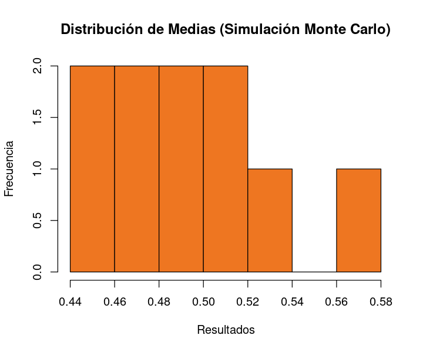

```r
hist(Resultados, main = "Distribución de Medias (Simulación Monte Carlo)",
     col= "chocolate2", ylab = "Frecuencia")
```

## Incrementemos el número de repeticiones:

```r
n <- 100
m <- 100

Resultados <- vector("numeric", length = m)

for (i in 1:m) {

    Resultados[i] <- mean(sample(1:2, size = n, replace = TRUE) == 1)

}

head(Resultados, 20)
```

1. 0.42

2. 0.46

3. 0.46

4. 0.5

5. 0.5

6. 0.58

7. 0.51

8. 0.46

9. 0.43

10. 0.43

11. 0.58

12. 0.5

13. 0.4

14. 0.53

15. 0.46

16. 0.57

17. 0.52

18. 0.47

19. 0.66

20. 0.52

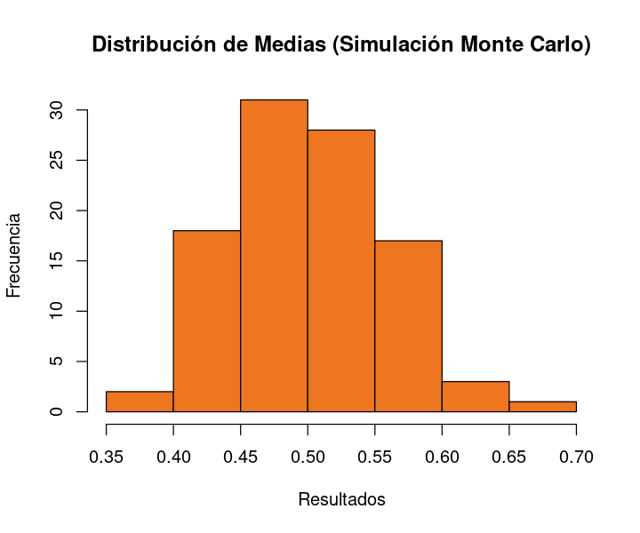

```r
hist(Resultados, main = "Distribución de Medias (Simulación Monte Carlo)", col = "chocolate2",
    ylab = "Frecuencia")
```

## Incrementemos drásticamente el número de lanzamientos y el número repeticiones:

```r
n <- 10000
m <- 10000

Resultados <- vector("numeric", length = m)

for (i in 1:m) {

    Resultados[i] <- mean(sample(1:2, size = n, replace = TRUE) == 1)

}

head(Resultados, 20)
```

1. 0.5006

2. 0.4902

3. 0.4954

4. 0.5015

5. 0.4938

6. 0.5006

7. 0.5069

8. 0.5004

9. 0.4996

10. 0.5066

11. 0.5075

12. 0.495

13. 0.4963

14. 0.4999

15. 0.5014

16. 0.4978

17. 0.5017

18. 0.4971

19. 0.4901

20. 0.4969

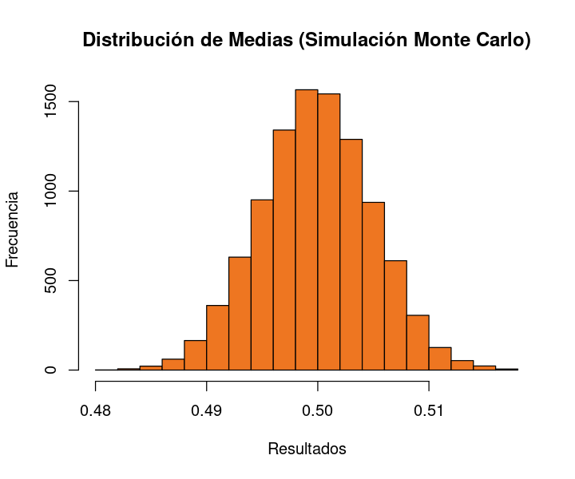

```r
hist(Resultados, main = "Distribución de Medias (Simulación Monte Carlo)", col = "chocolate2",
    ylab = "Frecuencia")
```

- ¿Qué podemos decir acerca de esta última distribución?
- ¿Qué podemos decir de su media?
- ¿Qué podemos decir de su desviación estándar?

Regresar al menú

# Simulación Monte Carlo: Aproximación a Pi

Sabiendo que la relación entre las áreas de un cuadrado de lado L = 2 y el círculo inscrito de radio r = 1 es:

\begin{equation} \frac{A_{círculo}}{A_{cuadrado}} = \frac{\Pi}{4} \end{equation}

lo que implica:

\begin{equation} \Pi = \frac{4A_{círculo}}{A_{cuadrado}} \end{equation}

Podemos aproximar el valor de $\Pi$, "lanzando" piedras aleatoriamente al cuadrado y calculando la relación de cuántas de ellas caen dentro del círculo.

```r
ran_point <- function() {

    # Autor: Francisco Jaramillo https://www.pakin.lat/

    coords <- list(c(runif(1, -1, 1), runif(1, -1, 1)))
    return(coords)
}
```

```r
circ_proof <- function(a) {

    # Autor: Francisco Jaramillo https://www.pakin.lat/

    r_norm <- sqrt(a[[1]][1]^2 + a[[1]][2]^2)
    return(r_norm)
}
```

```r
nPuntos <- c(10, 100, 1000, 1500, 5000, 10000, 15000, 1e+05, 150000, 5e+05, 1e+06)

PiMonteCarlo <- function(){

    # Autor: Francisco Jaramillo https://www.pakin.lat/

    for (j in 1:length(nPuntos)) {


        dentro <- 0
        fuera <- 0

        p_dentro <- list()
        p_fuera <- list()


        for (i in 1:nPuntos[j]) {


            punto <- ran_point()
            ld <- length(p_dentro)
            lf <- length(p_fuera)


            if (circ_proof(punto) <= 1) {


                dentro <- dentro + 1
                p_dentro[ld + 1] <- punto

            } else {


                fuera <- fuera + 1
                p_fuera[lf + 1] <- c(punto)

            }
        }


     print(paste("No. Puntos = ", i, ",", "Pi ~", round(dentro/nPuntos[j] * 4, digits = 6)))

    }
}
```

[output not shown]

[figure not shown]

Regresar al inicio

## Síguenos, pregunta y comenta en:

[figure not shown]